# MLP Classifier

```python
import pandas as pd
import os
import matplotlib.pyplot as plt
import numpy as np
import random


from sklearn.model_selection import train_test_split
from sklearn.metrics import classification_report,confusion_matrix
from sklearn.linear_model import LogisticRegression
from sklearn.preprocessing import StandardScaler
from sklearn.neural_network import MLPClassifier
from sklearn.model_selection import learning_curve
from sklearn import cross_validation
from sklearn.utils import  shuffle
from sklearn.model_selection import KFold
```

```python
os.chdir("D:\\DataPlay\\TeachingMaterial")
random.seed(10)
```

```python
def plot_learning_curve(estimator, title, X, y, ylim=None, cv=None,
                        n_jobs=None, train_sizes=np.linspace(.1, 1.0, 5)):
    plt.figure()
    plt.title(title)
    if ylim is not None:
        plt.ylim(*ylim)
    plt.xlabel("Training examples")
    plt.ylabel("Score")
    train_sizes, train_scores, test_scores = learning_curve(estimator, X, y, cv=cv, n_jobs=n_jobs, train_sizes=train_sizes)

    train_scores_mean = np.mean(train_scores, axis=1)
    train_scores_std = np.std(train_scores, axis=1)
    test_scores_mean = np.mean(test_scores, axis=1)
    test_scores_std = np.std(test_scores, axis=1)

    plt.grid()

    plt.fill_between(train_sizes, train_scores_mean - train_scores_std,
                     train_scores_mean + train_scores_std, alpha=0.1,
                     color="r")
    plt.fill_between(train_sizes, test_scores_mean - test_scores_std,
                     test_scores_mean + test_scores_std, alpha=0.1, color="g")
    plt.plot(train_sizes, train_scores_mean, 'o-', color="r",
             label="Training score")
    plt.plot(train_sizes, test_scores_mean, 'o-', color="g",
             label="Cross-validation score")

    plt.legend(loc="best")
    return plt
```

It has various chemical features of different wines, all grown in the same region in Italy, but the data is labeled by three different possible cultivars.

We will try to build a model that can classify what cultivar a wine belongs to based on its chemical features using Neural Networks.

```python
wine = pd.read_csv('wine_data.csv', names = ["Cultivator", "Alchol", "Malic_Acid", "Ash", "Alcalinity_of_Ash", "Magnesium", "Total_phenols", "Falvanoids", "Nonflavanoid_phenols", "Proanthocyanins", "Color_intensity", "Hue", "OD280", "Proline"])
```

```python
wine.head()
```

|  | Cultivator | Alchol | Malic_Acid | Ash | Alcalinity_of_Ash | Magnesium | Total_phenols | Falvanoids | Nonflavanoid_phenols | Proanthocyanins | Color_intensity | Hue | OD280 | Proline |
| --- | --- | --- | --- | --- | --- | --- | --- | --- | --- | --- | --- | --- | --- | --- |
| 0 | 1 | 14.23 | 1.71 | 2.43 | 15.6 | 127 | 2.80 | 3.06 | 0.28 | 2.29 | 5.64 | 1.04 | 3.92 | 1065 |
| 1 | 1 | 13.20 | 1.78 | 2.14 | 11.2 | 100 | 2.65 | 2.76 | 0.26 | 1.28 | 4.38 | 1.05 | 3.40 | 1050 |
| 2 | 1 | 13.16 | 2.36 | 2.67 | 18.6 | 101 | 2.80 | 3.24 | 0.30 | 2.81 | 5.68 | 1.03 | 3.17 | 1185 |
| 3 | 1 | 14.37 | 1.95 | 2.50 | 16.8 | 113 | 3.85 | 3.49 | 0.24 | 2.18 | 7.80 | 0.86 | 3.45 | 1480 |
| 4 | 1 | 13.24 | 2.59 | 2.87 | 21.0 | 118 | 2.80 | 2.69 | 0.39 | 1.82 | 4.32 | 1.04 | 2.93 | 735 |

Checking the distribution of each label in wine Cultivator

```python
wine.Cultivator.value_counts(dropna= False)
```

```
2    71
1    59
3    48
Name: Cultivator, dtype: int64
```

```python
wine.describe().transpose()
```

|  | count | mean | std | min | 25% | 50% | 75% | max |
| --- | --- | --- | --- | --- | --- | --- | --- | --- |
| Cultivator | 178.0 | 1.938202 | 0.775035 | 1.00 | 1.0000 | 2.000 | 3.0000 | 3.00 |
| Alchol | 178.0 | 13.000618 | 0.811827 | 11.03 | 12.3625 | 13.050 | 13.6775 | 14.83 |
| Malic_Acid | 178.0 | 2.336348 | 1.117146 | 0.74 | 1.6025 | 1.865 | 3.0825 | 5.80 |
| Ash | 178.0 | 2.366517 | 0.274344 | 1.36 | 2.2100 | 2.360 | 2.5575 | 3.23 |
| Alcalinity_of_Ash | 178.0 | 19.494944 | 3.339564 | 10.60 | 17.2000 | 19.500 | 21.5000 | 30.00 |
| Magnesium | 178.0 | 99.741573 | 14.282484 | 70.00 | 88.0000 | 98.000 | 107.0000 | 162.00 |
| Total_phenols | 178.0 | 2.295112 | 0.625851 | 0.98 | 1.7425 | 2.355 | 2.8000 | 3.88 |
| Falvanoids | 178.0 | 2.029270 | 0.998859 | 0.34 | 1.2050 | 2.135 | 2.8750 | 5.08 |
| Nonflavanoid_phenols | 178.0 | 0.361854 | 0.124453 | 0.13 | 0.2700 | 0.340 | 0.4375 | 0.66 |
| Proanthocyanins | 178.0 | 1.590899 | 0.572359 | 0.41 | 1.2500 | 1.555 | 1.9500 | 3.58 |
| Color_intensity | 178.0 | 5.058090 | 2.318286 | 1.28 | 3.2200 | 4.690 | 6.2000 | 13.00 |
| Hue | 178.0 | 0.957449 | 0.228572 | 0.48 | 0.7825 | 0.965 | 1.1200 | 1.71 |
| OD280 | 178.0 | 2.611685 | 0.709990 | 1.27 | 1.9375 | 2.780 | 3.1700 | 4.00 |
| Proline | 178.0 | 746.893258 | 314.907474 | 278.00 | 500.5000 | 673.500 | 985.0000 | 1680.00 |

Separating Labels and Features

```python
X = wine.drop('Cultivator',axis=1)
Y = wine['Cultivator']
```

```python
X_train, X_test, y_train, y_test = train_test_split(X, y)
```

```
                                        Standard Scaling
```

This method is widely used for normalization in many machine learning algorithms (e.g., support vector machines, logistic regression, and artificial neural networks.

The general method of calculation is to determine the distribution mean and standard deviation for each feature.

Next we subtract the mean from each feature.

Then we divide the values (mean is already subtracted) of each feature by its standard deviation.

[figure not shown]

```python
scaler = StandardScaler()
# Fit only to the training data
scaler.fit(X_train)
# Now apply the transformations to the data:
X_train = scaler.transform(X_train)
X_test = scaler.transform(X_test)
```

```
                                Multi-layer Perceptron classifier
```

How long should you train the net? basically setting value of max_iterations , if for certain number of iterations cost fucntion doesn't decrease below a certain threshold training automatically stops

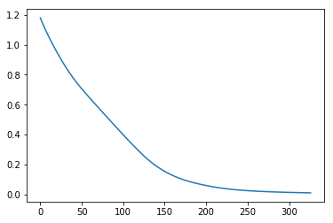

```python
mlp = MLPClassifier(hidden_layer_sizes=(13,13,13),max_iter=10000,validation_fraction=0.2)
mlp.fit(X_train,y_train)
plt.plot(mlp.loss_curve_)
plt.show()
```

```
            How to measure performance of Model Trained
```

To evaluate the performance of any machine learning model we need to test it on some unseen data.

```python
predictions_probability = mlp.predict_proba(X_test)
predictions = mlp.predict(X_test)
print(classification_report(y_test,predictions))
```

[output not shown]

```
            How to ensure model trained is generalising and well built means will perform equally good across all test
                ->Cross Validation
```

Cross validation (CV) is one of the technique used to test the effectiveness of a machine learning models, it is also a re-sampling procedure used to evaluate a model if we have a limited data.

Cross Validation is used to ensure if model is overfitting or underfitting.

To perform CV we need to keep aside a sample/portion of the data on which is do not use to train the model, later us this sample for testing/validating.

Cross Validation is of two types

Train Test Split / KFold Split

[figure not shown]

The below MLP Classifier is trained including cross validation approach. X axis basically represents the training set size. How does training accuracy is versus cross validation accuracy.

```python
neural_net = MLPClassifier()
cv = KFold(n_splits= 3, shuffle=False, random_state=None)
plot_learning_curve(neural_net,"Score", X_train, y_train, cv=cv, n_jobs=-1)
plt.show()
```

[output not shown]

```
                    What is overfitting and underfitting?
```

[figure not shown]

Performance of Logistic regression ?

```python
clf = LogisticRegression(random_state=0, solver='lbfgs').fit(X_train, y_train)
predictions = clf.predict(X_test)
print(classification_report(y_test,predictions))
```

[output not shown]